# Lab 06 - Permutational Testing in Regression

## Parenthesis: a possible use of the DDplot

In Lab $01$ we saw the Depth-Depth plot, which is a Nonparametric explorative visual tool to compare two populations. It is actually a nonparametric generalisation of the qqplot, however: * It also works with multivariate data * It uses depths that are computed w.r.t the available sample. So we do not compare the empirical depths (which replace the quantiles) with theoretical ones, but with the depths of another sample.

The interpretation is the same as in the qqplot. If we see approximately a straight line, it means that both (empirical) distributions are similar.

Thus, if we wanted to see the e.c.d.f. of the residuals w.r.t a normal one, we would have to build a DD-plot where one sample is the one of the residuals, and the other one of a normal distribution.

(Note that to make them comparable, I sampled from a normal distribution with the same variance as the residuals, which is in turn estimated in the $lm$ object.)

```
## DDPlot
```

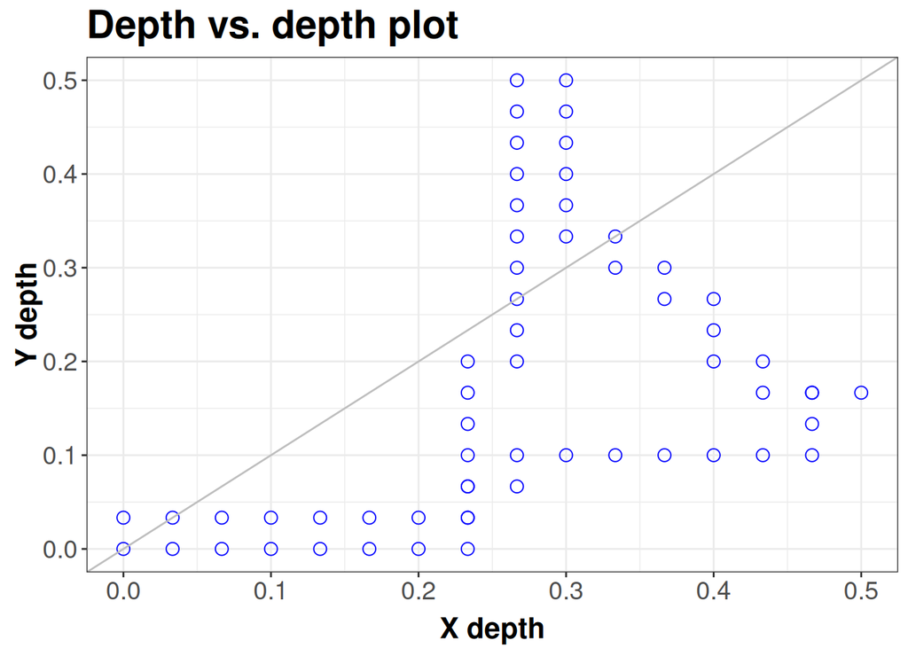

```
##
## Depth Metohod:
##   Tukey
```

```r
n <- length(result$residuals)
set.seed(1992)
normal <- as.matrix(rnorm(n,
                          sd=summary.lm(result)$sigma))  # unbiased estimate of residual variance

DepthProc::ddPlot(x = as.matrix(normal), # use as.matrix since ddplot usually receives multivariate data
                  y = as.matrix(as.matrix(result$residuals)),depth_params = list(method='Tukey'))
```

We notice that the points go far away from the $y=x$ line. Naturally, if we compared two samples from the same normal distribution, we would have a very high correlation in the depths:

```
## DDPlot
```

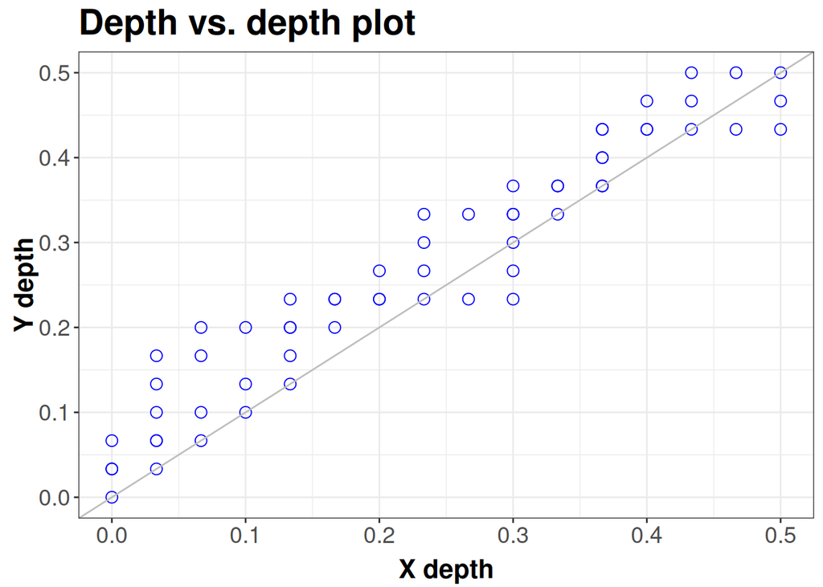

```
##
## Depth Metohod:
##   Tukey
```

```r
normal <- as.matrix(rnorm(n,
                          sd=summary.lm(result)$sigma))  # unbiased estimate of residual variance
normal2 <- as.matrix(rnorm(n,
                          sd=summary.lm(result)$sigma))


DepthProc::ddPlot(x = normal, y = normal2 ,depth_params = list(method='Tukey'))
```

And the conclusion we gather from such DD-plot is that the samples are indeed quite likely to be from the same distribution.

[^1]: If you clicked this footnote, perhaps you were looking for the solution. What was the main message of Lab$03$?
[^2]: Again you just have to know it could be a good choice for this scenario. For further details I refer you again to the book of Applied statistics.